# Summer Internship

Navin Ramanan

6/01/2022

##Setup

1. Map Ensembl ID to Gene Symbol in the counts file

```
## Ensembl site unresponsive, trying www mirror
## Ensembl site unresponsive, trying www mirror
```

2. Write Counts Data with Gene Symbol to CSV
3. Reading and filtering Hippocampus count and metadata files
4. Reading and filtering Cortex count and metadata files
5. Cortex: APP=WT, Age=3, Diet=Control vs Supplemented (~APP + Age + Diet) WT3Control vs WT3Supplemented

```
## Cortex: Running DESeq2 for Diet(Control vs Supplemented) with APP=WT, Age=3:padj < 0.05 and 0.10
```

```
## Cortex: WT3Control vs WT3Supplemented
```

```
## resultsNames:
```

```
##  [1] "Intercept"
##  [2] "group_APP12Supplemented_vs_APP12Control"
##  [3] "group_APP3Control_vs_APP12Control"
##  [4] "group_APP3Supplemented_vs_APP12Control"
##  [5] "group_APP6Control_vs_APP12Control"
##  [6] "group_APP6Supplemented_vs_APP12Control"
##  [7] "group_APP9Control_vs_APP12Control"
##  [8] "group_APP9Supplemented_vs_APP12Control"
##  [9] "group_WT12Control_vs_APP12Control"
## [10] "group_WT12Supplemented_vs_APP12Control"
## [11] "group_WT3Control_vs_APP12Control"
## [12] "group_WT3Supplemented_vs_APP12Control"
## [13] "group_WT6Control_vs_APP12Control"
## [14] "group_WT6Supplemented_vs_APP12Control"
## [15] "group_WT9Control_vs_APP12Control"
## [16] "group_WT9Supplemented_vs_APP12Control"
## [1] "group"           "WT3Control"      "WT3Supplemented"
##
## out of 34880 with nonzero total read count
## adjusted p-value < 0.1
## LFC > 0 (up)       : 2, 0.0057%
## LFC < 0 (down)     : 1, 0.0029%
## outliers [1]       : 101, 0.29%
## low counts [2]     : 0, 0%
## (mean count < 0)
## [1] see 'cooksCutoff' argument of ?results
## [2] see 'independentFiltering' argument of ?results
```

```
## log2 fold change (MLE): group WT3Control vs WT3Supplemented
## Wald test p-value: group WT3Control vs WT3Supplemented
## DataFrame with 10 rows and 6 columns
##                     baseMean log2FoldChange     lfcSE      stat      pvalue
##                    <numeric>      <numeric> <numeric> <numeric>   <numeric>
## ENSMUSG00000006204  6.281958      18.727843  1.563552 11.977751 4.64759e-33
## ENSMUSG00000110266  1.672628      18.158037  2.962014  6.130300 8.77134e-10
## ENSMUSG00000050366  1.420786     -16.694986  3.021767 -5.524909 3.29656e-08
## ENSMUSG00000102628 17.922102      -0.502801  0.500039 -1.005524 3.14645e-01
## ENSMUSG00000097426  0.160601       0.000000  8.245409  0.000000 1.00000e+00
## ENSMUSG00000086053  1.154142       0.236949  1.582428  0.149738 8.80972e-01
## ENSMUSG00000102135  0.631465       0.847994  2.167781  0.391180 6.95664e-01
## ENSMUSG00000100764  6.120378       0.236623  0.625865  0.378074 7.05376e-01
## ENSMUSG00000102095  0.498763       1.149058  2.395272  0.479719 6.31427e-01
## ENSMUSG00000100635  5.830331      -0.715686  0.739050 -0.968387 3.32851e-01
##                           padj
##                      <numeric>
## ENSMUSG00000006204 1.61639e-28
## ENSMUSG00000110266 1.52529e-05
## ENSMUSG00000050366 3.82170e-04
## ENSMUSG00000102628 1.00000e+00
## ENSMUSG00000097426 1.00000e+00
## ENSMUSG00000086053 1.00000e+00
## ENSMUSG00000102135 1.00000e+00
## ENSMUSG00000100764 1.00000e+00
## ENSMUSG00000102095 1.00000e+00
## ENSMUSG00000100635 1.00000e+00
```

```
## log2 fold change (MLE): group WT3Control vs WT3Supplemented
## Wald test p-value: group WT3Control vs WT3Supplemented
## DataFrame with 34880 rows and 6 columns
##                       baseMean log2FoldChange     lfcSE      stat      pvalue
##                      <numeric>      <numeric> <numeric> <numeric>   <numeric>
## ENSMUSG00000006204    6.281958      18.727843  1.563552  11.97775 4.64759e-33
## ENSMUSG00000110266    1.672628      18.158037  2.962014   6.13030 8.77134e-10
## ENSMUSG00000050366    1.420786     -16.694986  3.021767  -5.52491 3.29656e-08
## ENSMUSG00000102628   17.922102      -0.502801  0.500039  -1.00552 3.14645e-01
## ENSMUSG00000097426    0.160601       0.000000  8.245409   0.00000 1.00000e+00
## ...                        ...            ...       ...       ...         ...
## ENSMUSG00000109212    0.769426       0.000000  8.245409  0.000000          NA
## ENSMUSG00000054134   40.269651      -0.708997  0.757785 -0.935618          NA
## ENSMUSG00000024028    0.789155       0.000000  8.245409  0.000000          NA
## ENSMUSG00000061808 1664.189531      -1.539048  0.829616 -1.855133          NA
## ENSMUSG00000037451    1.547250       0.000000  8.245409  0.000000          NA
##                           padj
##                      <numeric>
## ENSMUSG00000006204 1.61639e-28
## ENSMUSG00000110266 1.52529e-05
## ENSMUSG00000050366 3.82170e-04
## ENSMUSG00000102628 1.00000e+00
## ENSMUSG00000097426 1.00000e+00
## ...                        ...
## ENSMUSG00000109212          NA
## ENSMUSG00000054134          NA
## ENSMUSG00000024028          NA
## ENSMUSG00000061808          NA
## ENSMUSG00000037451          NA
```

```
## class: DESeqDataSet
## dim: 34880 96
## metadata(1): version
## assays(4): counts mu H cooks
## rownames(34880): ENSMUSG00000102628 ENSMUSG00000097426 ...
##   ENSMUSG00000095041 ENSMUSG00000095742
## rowData names(78): baseMean baseVar ... deviance maxCooks
## colnames(96): 102 103 ... 95 96
## colData names(6): Sex Diet ... group sizeFactor
```

```
## Cortex DESeq2 result is saved in file: 'Cortex_deseq_results_Diet_WT_3.csv'
```

```
## Cortex DESeq2 normalized counts is saved in file: 'Cortex_deseq_norm_counts_Diet_WT_3.csv'
```

```
## Cortex DESeq2 result with Gene names (mgi_symbols) is saved in file: 'Cortex_deseq_results_with_genename_Diet_WT_3.csv'
```

```
## [1] 34880
```

```
## [1] 3
```

```
## Cortex DESeq2 result after padj (0.05) filtering is saved in file: 'Cortex_deseq_results_Diet_WT_3_padj_05_filtered.csv'
```

```
## Number of DE genes significant at padj < 0.05 for Cortex:WT3Control vs WT3Supplemented: 3
```

```
## Number of DE genes discarded after padj threshold 0.05 filtering for Cortex:WT3Control vs WT3Supplemented: 34877
```

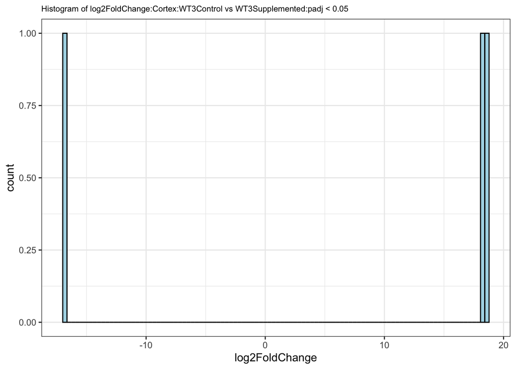

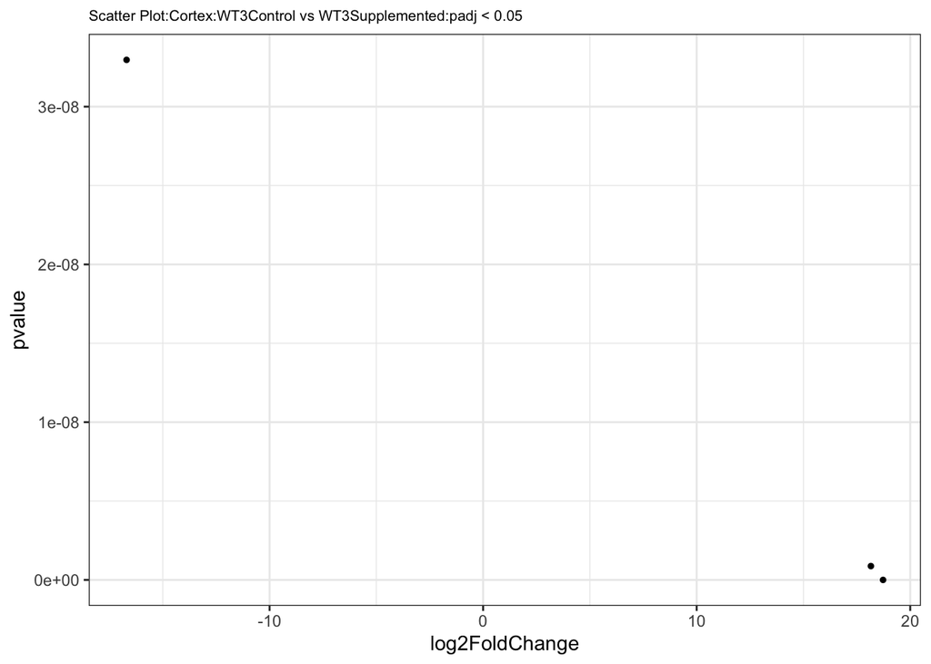

```
## [1] 34880
```

```
## [1] 3
```

```
## Cortex DESeq2 result after padj (0.1) filtering is saved in file: 'Cortex_deseq_results_Diet_WT_3_padj_1_filtered.csv'
```

```
## Number of DE genes significant at padj < 0.1 for Cortex:WT3Control vs WT3Supplemented: 3
```

```
## Number of DE genes discarded after padj threshold 0.1 filtering for Cortex:WT3Control vs WT3Supplemented: 34877
```

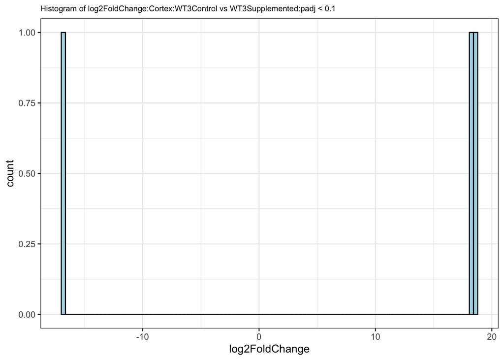

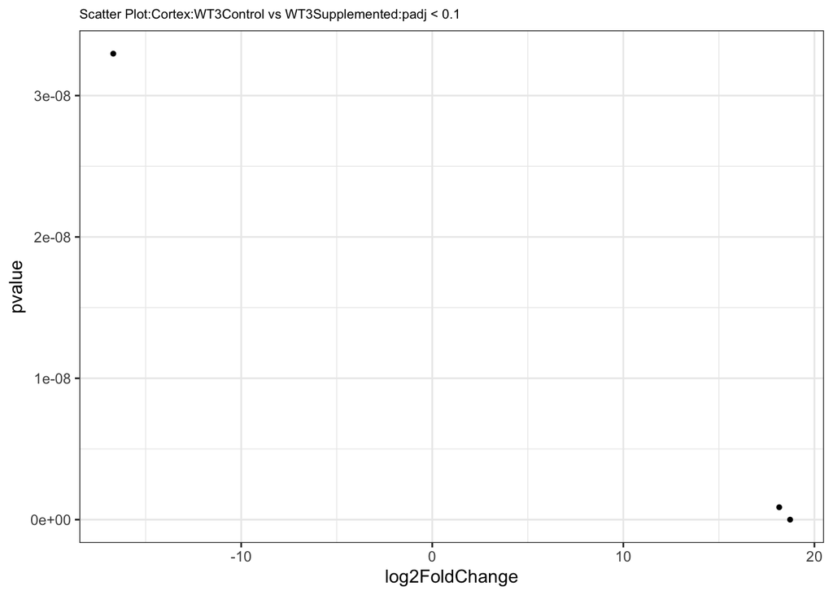

6. Cortex: Enhanced Volcano Plot

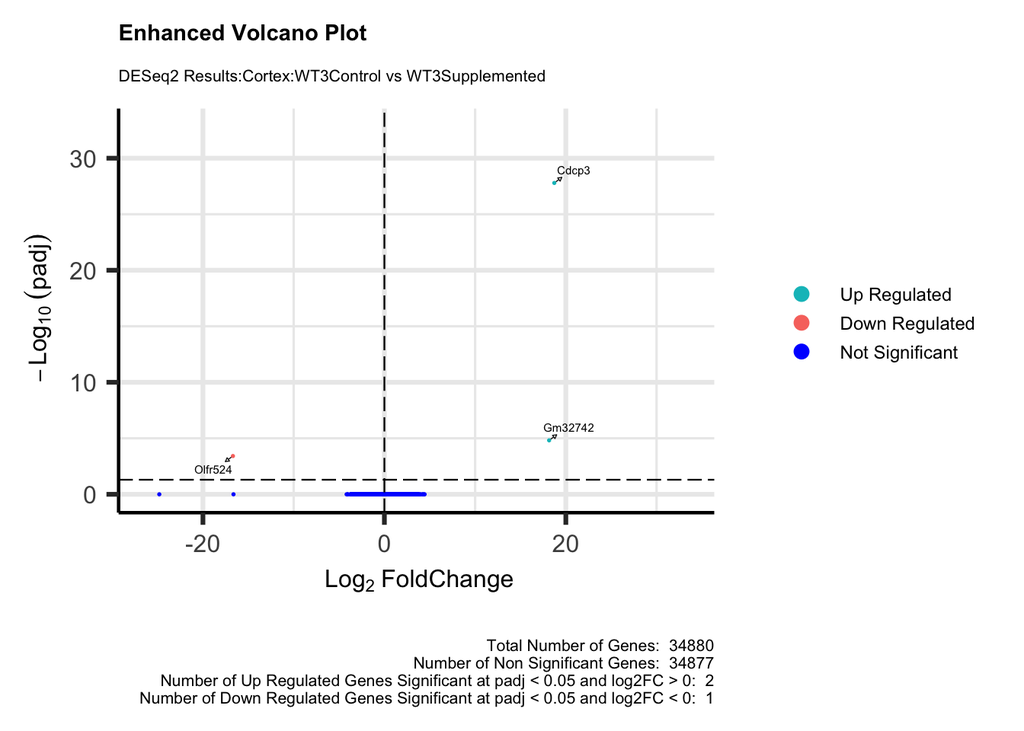

7. Cortex: Heatmap

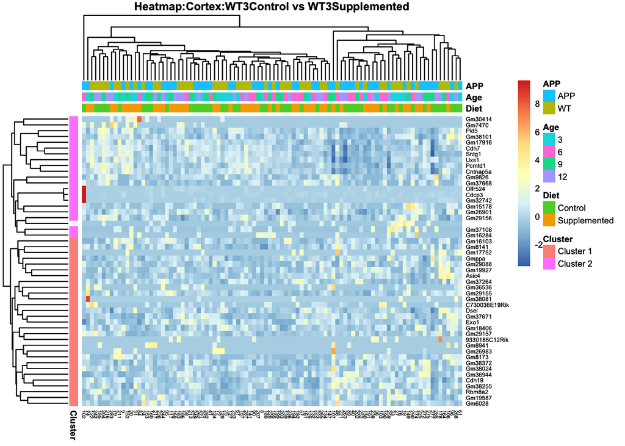

8. Hippocampus: APP=WT, Age=3, Diet=Control vs Supplemented (~APP + Age + Diet) WT3Control vs WT3Supplemented

```
## Hippocampus: Running DESeq2 for Diet(Control vs Supplemented) with APP=WT, Age=3:padj < 0.05 and 0.10
```

```
## Hippocampus: WT3Control vs WT3Supplemented
```

```
## resultsNames:
```

```
##  [1] "Intercept"
##  [2] "group_APP12Supplemented_vs_APP12Control"
##  [3] "group_APP3Control_vs_APP12Control"
##  [4] "group_APP3Supplemented_vs_APP12Control"
##  [5] "group_APP6Control_vs_APP12Control"
##  [6] "group_APP6Supplemented_vs_APP12Control"
##  [7] "group_APP9Control_vs_APP12Control"
##  [8] "group_APP9Supplemented_vs_APP12Control"
##  [9] "group_WT12Control_vs_APP12Control"
## [10] "group_WT12Supplemented_vs_APP12Control"
## [11] "group_WT3Control_vs_APP12Control"
## [12] "group_WT3Supplemented_vs_APP12Control"
## [13] "group_WT6Control_vs_APP12Control"
## [14] "group_WT6Supplemented_vs_APP12Control"
## [15] "group_WT9Control_vs_APP12Control"
## [16] "group_WT9Supplemented_vs_APP12Control"
## [1] "group"           "WT3Control"      "WT3Supplemented"
##
## out of 33271 with nonzero total read count
## adjusted p-value < 0.1
## LFC > 0 (up)       : 0, 0%
## LFC < 0 (down)     : 0, 0%
## outliers [1]       : 77, 0.23%
## low counts [2]     : 0, 0%
## (mean count < 0)
## [1] see 'cooksCutoff' argument of ?results
## [2] see 'independentFiltering' argument of ?results
```

```
## log2 fold change (MLE): group WT3Control vs WT3Supplemented
## Wald test p-value: group WT3Control vs WT3Supplemented
## DataFrame with 10 rows and 6 columns
##                       baseMean log2FoldChange     lfcSE       stat      pvalue
##                      <numeric>      <numeric> <numeric>  <numeric>   <numeric>
## ENSMUSG00000104212    5.852899     -4.2554143  1.036677 -4.1048588 4.04562e-05
## ENSMUSG00000085861    3.314957      4.7580164  1.155555  4.1175155 3.82979e-05
## ENSMUSG00000102628    4.933073      0.6008473  0.720606  0.8338086 4.04389e-01
## ENSMUSG00000086053    1.288311     -0.5816741  1.663423 -0.3496850 7.26575e-01
## ENSMUSG00000102135    0.260071      0.1574486  4.987618  0.0315679 9.74817e-01
## ENSMUSG00000100764    7.786530     -0.0752524  0.691578 -0.1088126 9.13351e-01
## ENSMUSG00000100635   10.643846      0.5172162  0.978868  0.5283818 5.97234e-01
## ENSMUSG00000100480   40.881695     -0.1594880  0.341546 -0.4669598 6.40529e-01
## ENSMUSG00000100025    9.761216      0.8797707  0.525598  1.6738458 9.41609e-02
## ENSMUSG00000051285 7467.607010      0.2437314  0.225315  1.0817350 2.79370e-01
##                         padj
##                    <numeric>
## ENSMUSG00000104212  0.671452
## ENSMUSG00000085861  0.671452
## ENSMUSG00000102628  1.000000
## ENSMUSG00000086053  1.000000
## ENSMUSG00000102135  1.000000
## ENSMUSG00000100764  1.000000
## ENSMUSG00000100635  1.000000
## ENSMUSG00000100480  1.000000
## ENSMUSG00000100025  1.000000
## ENSMUSG00000051285  1.000000
```

```
## log2 fold change (MLE): group WT3Control vs WT3Supplemented
## Wald test p-value: group WT3Control vs WT3Supplemented
## DataFrame with 33271 rows and 6 columns
##                       baseMean log2FoldChange     lfcSE       stat      pvalue
##                      <numeric>      <numeric> <numeric>  <numeric>   <numeric>
## ENSMUSG00000104212    5.852899      -4.255414  1.036677 -4.1048588 4.04562e-05
## ENSMUSG00000085861    3.314957       4.758016  1.155555  4.1175155 3.82979e-05
## ENSMUSG00000102628    4.933073       0.600847  0.720606  0.8338086 4.04389e-01
## ENSMUSG00000086053    1.288311      -0.581674  1.663423 -0.3496850 7.26575e-01
## ENSMUSG00000102135    0.260071       0.157449  4.987618  0.0315679 9.74817e-01
## ...                        ...            ...       ...        ...         ...
## ENSMUSG00000068196   434.29152       0.235034   1.19502  0.1966775          NA
## ENSMUSG00000053375     1.58633      -0.283166   3.17201 -0.0892700          NA
## ENSMUSG00000023122    38.89638       0.102639   2.47116  0.0415347          NA
## ENSMUSG00000023943    18.46229      -0.868681   2.59871 -0.3342741          NA
## ENSMUSG00000061808 34756.71162      -1.586327   1.53464 -1.0336819          NA
##                         padj
##                    <numeric>
## ENSMUSG00000104212  0.671452
## ENSMUSG00000085861  0.671452
## ENSMUSG00000102628  1.000000
## ENSMUSG00000086053  1.000000
## ENSMUSG00000102135  1.000000
## ...                      ...
## ENSMUSG00000068196        NA
## ENSMUSG00000053375        NA
## ENSMUSG00000023122        NA
## ENSMUSG00000023943        NA
## ENSMUSG00000061808        NA
```

```
## class: DESeqDataSet
## dim: 33271 96
## metadata(1): version
## assays(4): counts mu H cooks
## rownames(33271): ENSMUSG00000102628 ENSMUSG00000086053 ...
##   ENSMUSG00000095041 ENSMUSG00000095742
## rowData names(78): baseMean baseVar ... deviance maxCooks
## colnames(96): 102 103 ... 95 96
## colData names(6): Sex Diet ... group sizeFactor
```

```
## Hippocampus DESeq2 result is saved in file: 'Hippocampus_deseq_results_Diet_WT_3.csv'
```

```
## Hippocampus DESeq2 normalized counts is saved in file: 'Hippocampus_deseq_norm_counts_Diet_WT_3.csv'
```

```
## Hippocampus DESeq2 result with Gene names (mgi_symbols) is saved in file: 'Hippocampus_deseq_results_with_genename_Diet_WT_3.csv'
```

```
## Hippocampus DESeq2 result after padj (0.05) filtering is saved in file: 'Hippocampus_deseq_results_Diet_WT_3_padj_05_filtered.csv'
```

```
## Number of DE genes significant at padj < 0.05 for Hippocampus:WT3Control vs WT3Supplemented: 0
```

```
## Number of DE genes discarded after padj threshold < 0.05 filtering for Hippocampus:WT3Control vs WT3Supplemented: 33271
```

[figure not shown]

[figure not shown]

```
## Hippocampus DESeq2 result after padj (0.1) filtering is saved in file: 'Hippocampus_deseq_results_Diet_WT_3_padj_1_filtered.csv'
```

```
## Number of DE genes significant at padj < 0.1 for Hippocampus:WT3Control vs WT3Supplemented: 0
```

```
## Number of DE genes discarded after padj threshold < 0.1 filtering for Hippocampus:WT3Control vs WT3Supplemented: 33271
```

[figure not shown]

[figure not shown]

9. Hippocampus: Enhanced Volcano Plot

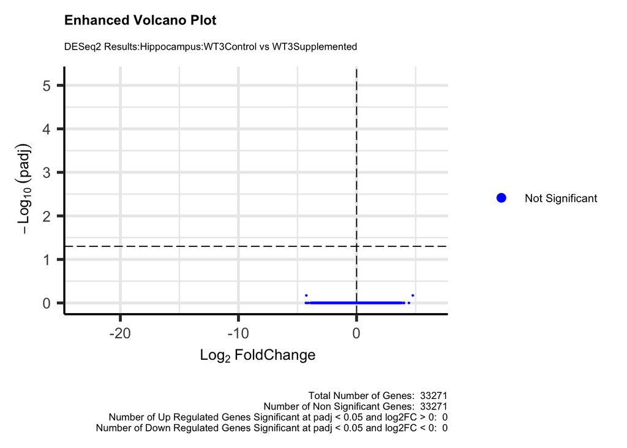

10. Hippocampus: Heatmap

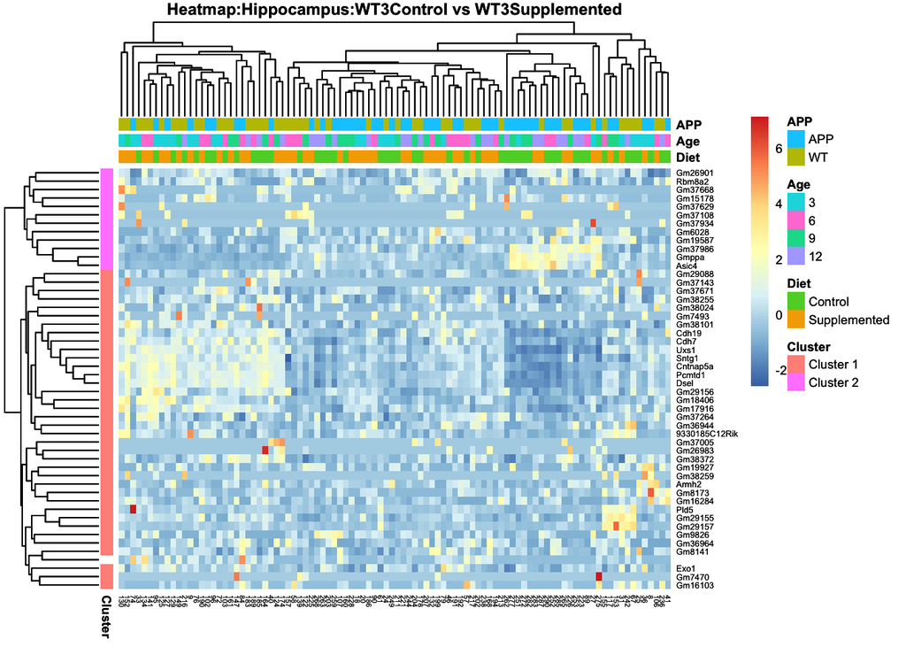

11. GSEA:Running fgsea

Perform a GSEA using a ranked list log2FoldChange values for all genes discovered in the DESeq2 results against the M2 Canonical Pathways gene set collection. Convert gene identifiers in the results to the appropriate matching format found in the M2 gene sets. fgsea expects a named vector of gene level statistics and the gene sets in the form of a named list.

Using “m2.cp.wikipathways.v0.3.symbols.gmt” which is the Canonical Pathways gene sets derived from the WikiPathways pathway database (WikiPathways subset of CP)

```
## # A tibble: 34,880 × 8
##    genes              volc_plot…¹ log2F…²     padj baseM…³ lfcSE   stat   pvalue
##    <chr>              <chr>         <dbl>    <dbl>   <dbl> <dbl>  <dbl>    <dbl>
##  1 ENSMUSG00000006204 UP           18.7   1.62e-28   6.28  1.56  12.0   4.65e-33
##  2 ENSMUSG00000110266 UP           18.2   1.53e- 5   1.67  2.96   6.13  8.77e-10
##  3 ENSMUSG00000050366 DOWN        -16.7   3.82e- 4   1.42  3.02  -5.52  3.30e- 8
##  4 ENSMUSG00000102628 NS           -0.503 1   e+ 0  17.9   0.500 -1.01  3.15e- 1
##  5 ENSMUSG00000097426 NS            0     1   e+ 0   0.161 8.25   0     1   e+ 0
##  6 ENSMUSG00000086053 NS            0.237 1   e+ 0   1.15  1.58   0.150 8.81e- 1
##  7 ENSMUSG00000102135 NS            0.848 1   e+ 0   0.631 2.17   0.391 6.96e- 1
##  8 ENSMUSG00000100764 NS            0.237 1   e+ 0   6.12  0.626  0.378 7.05e- 1
##  9 ENSMUSG00000102095 NS            1.15  1   e+ 0   0.499 2.40   0.480 6.31e- 1
## 10 ENSMUSG00000100635 NS           -0.716 1   e+ 0   5.83  0.739 -0.968 3.33e- 1
## # … with 34,870 more rows, and abbreviated variable names ¹volc_plot_status,
## #   ²log2FoldChange, ³baseMean
## # ℹ Use `print(n = ...)` to see more rows
```

```
## # A tibble: 190 × 8
##    pathway                        pval   padj log2err     ES   NES  size leadi…¹
##    <chr>                         <dbl>  <dbl>   <dbl>  <dbl> <dbl> <int> <list>
##  1 WP_PROSTAGLANDIN_SYNTHESIS… 8.26e-4 0.0785   0.477 -0.767 -1.84    31 <chr>
##  2 WP_ESTROGEN_METABOLISM      2.16e-3 0.137    0.432 -0.896 -1.75    12 <chr>
##  3 WP_NUCLEAR_RECEPTORS_IN_LI… 2.51e-2 0.477    0.352 -0.699 -1.64    29 <chr>
##  4 WP_TRYPTOPHAN_METABOLISM    1.25e-2 0.298    0.381 -0.641 -1.64    44 <chr>
##  5 WP_AFLATOXIN_B1_METABOLISM  2.58e-4 0.0490   0.498 -0.984 -1.57     5 <chr>
##  6 WP_ELECTRON_TRANSPORT_CHAIN 6.91e-3 0.276    0.407 -0.541 -1.54    97 <chr>
##  7 WP_FATTY_ACID_OMEGAOXIDATI… 9.27e-3 0.276    0.381 -0.910 -1.53     6 <chr>
##  8 WP_OXIDATION_BY_CYTOCHROME… 1.81e-2 0.383    0.352 -0.604 -1.52    39 <chr>
##  9 WP_OMEGA9_FATTY_ACID_SYNTH… 8.85e-2 1        0.214 -0.691 -1.43    14 <chr>
## 10 WP_HYPOXIADEPENDENT_DIFFER… 1.64e-1 1        0.154 -0.650 -1.30    13 <chr>
## # … with 180 more rows, and abbreviated variable name ¹leadingEdge
## # ℹ Use `print(n = ...)` to see more rows
```

```
## Cortex NES ordered fgsea results saved in file: 'Cortex_NES_ordered_fgsea_results_Diet_WT_3_FC0.csv'
```

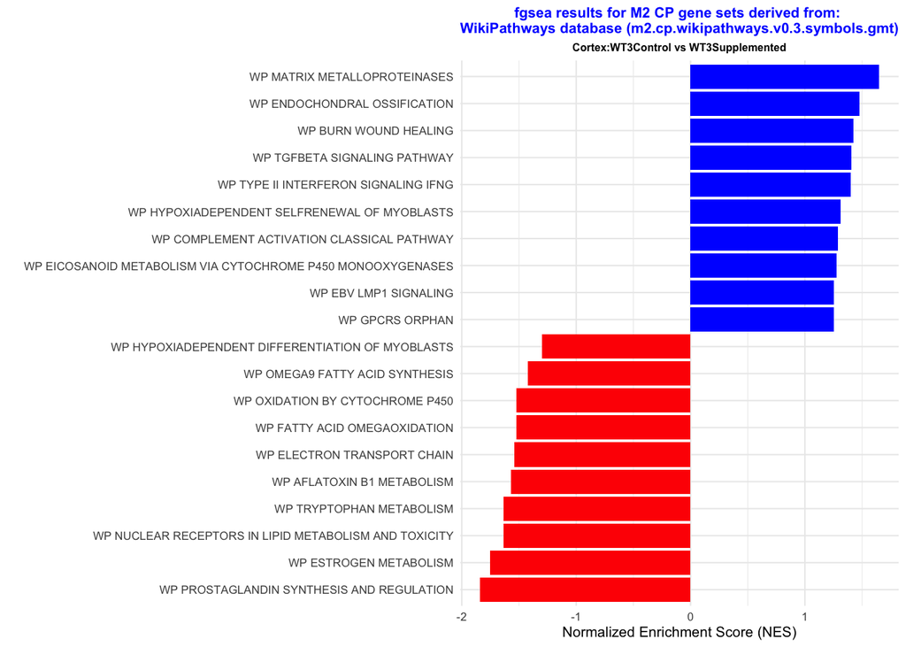

```
## # A tibble: 33,271 × 8
##    genes              volc_plot_st…¹ log2F…²  padj baseM…³ lfcSE    stat  pvalue
##    <chr>              <chr>            <dbl> <dbl>   <dbl> <dbl>   <dbl>   <dbl>
##  1 ENSMUSG00000104212 NS             -4.26   0.671 5.85e+0 1.04  -4.10   4.05e-5
##  2 ENSMUSG00000085861 NS              4.76   0.671 3.31e+0 1.16   4.12   3.83e-5
##  3 ENSMUSG00000102628 NS              0.601  1     4.93e+0 0.721  0.834  4.04e-1
##  4 ENSMUSG00000086053 NS             -0.582  1     1.29e+0 1.66  -0.350  7.27e-1
##  5 ENSMUSG00000102135 NS              0.157  1     2.60e-1 4.99   0.0316 9.75e-1
##  6 ENSMUSG00000100764 NS             -0.0753 1     7.79e+0 0.692 -0.109  9.13e-1
##  7 ENSMUSG00000100635 NS              0.517  1     1.06e+1 0.979  0.528  5.97e-1
##  8 ENSMUSG00000100480 NS             -0.159  1     4.09e+1 0.342 -0.467  6.41e-1
##  9 ENSMUSG00000100025 NS              0.880  1     9.76e+0 0.526  1.67   9.42e-2
## 10 ENSMUSG00000051285 NS              0.244  1     7.47e+3 0.225  1.08   2.79e-1
## # … with 33,261 more rows, and abbreviated variable names ¹volc_plot_status,
## #   ²log2FoldChange, ³baseMean
## # ℹ Use `print(n = ...)` to see more rows
```

```
## # A tibble: 190 × 8
##    pathway                        pval   padj log2err     ES   NES  size leadi…¹
##    <chr>                         <dbl>  <dbl>   <dbl>  <dbl> <dbl> <int> <list>
##  1 WP_EICOSANOID_METABOLISM_V… 4.91e-4 0.0471   0.477 -0.696 -1.83    30 <chr>
##  2 WP_GLUTATHIONE_METABOLISM   3.23e-3 0.123    0.432 -0.704 -1.68    20 <chr>
##  3 WP_INFLAMMATORY_RESPONSE_P… 7.04e-3 0.223    0.407 -0.632 -1.66    30 <chr>
##  4 WP_CYTOPLASMIC_RIBOSOMAL_P… 3.01e-3 0.123    0.432 -0.487 -1.56    90 <chr>
##  5 WP_EICOSANOID_METABOLISM_V… 2.35e-2 0.499    0.352 -0.571 -1.51    31 <chr>
##  6 WP_FOCAL_ADHESION           1.73e-3 0.110    0.455 -0.429 -1.50   185 <chr>
##  7 WP_FOCAL_ADHESION_PI3KAKTM… 4.96e-4 0.0471   0.477 -0.406 -1.49   301 <chr>
##  8 WP_GLUTATHIONE_AND_ONECARB… 2.85e-2 0.511    0.352 -0.560 -1.48    31 <chr>
##  9 WP_ACETYLCHOLINE_SYNTHESIS  5.33e-2 0.674    0.266 -0.788 -1.48     7 <chr>
## 10 WP_NUCLEAR_RECEPTORS_IN_LI… 2.36e-2 0.499    0.352 -0.570 -1.47    28 <chr>
## # … with 180 more rows, and abbreviated variable name ¹leadingEdge
## # ℹ Use `print(n = ...)` to see more rows
```

```
## Hippocampus NES ordered fgsea results saved in file: 'Hippocampus_NES_ordered_fgsea_results_Diet_WT_3_FC0.csv'
```

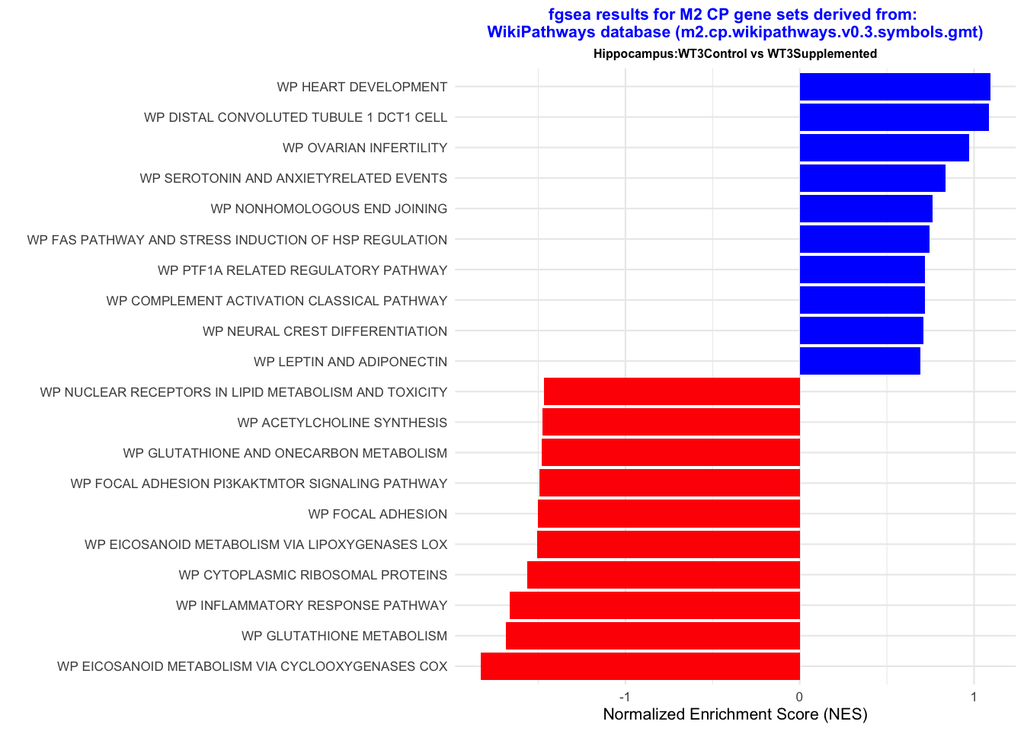